# Estudio sobre la depresión estudiantil. Grupo 5. Preprocesamiento

Miguel Encina Martinez, Daniel Galván Cancio, Jaime Linares Barrera, Daniel Vela Camacho

# Preprocesamiento

En este apartado realizamos las transformaciones necesarias para dejar nuestro dataset listo para análisis más avanzados y modelado predictivo. El objetivo es pasar de los datos brutos a una versión limpia, coherente y estructurada, reduciendo ruido y complejidad innecesaria y generando distintos **datasets derivados** adaptados a varios tipos de algoritmos de minería de datos.

A lo largo de este proceso abordamos, entre otros, los siguientes aspectos:

- Filtrado de participantes que no sean estudiantes.
- Eliminación de columnas irrelevantes o constantes.
- Limpieza de valores inconsistentes (como `"?"` o comillas en textos).
- Recodificación de variables categóricas binarias (“Yes”/“No”) a formato numérico.
- Tratamiento de variables ordinales (p. ej. duración del sueño, hábitos dietéticos).
- Reducción de la cardinalidad en variables categóricas con muchos niveles poco frecuentes (agrupamos ciudades por las más comunes y agrupamos grados por nivel académico).
- Conversión de variables categóricas a factores ordenados.
- Identificación y tratamiento de valores extremos en variables numéricas.
- Generación de diferentes versiones del dataset (con factores, numérica normalizada, numérica estandarizada).
- Reducción de dimensionalidad mediante **selección de atributos basada en Información Mutua**, conservando únicamente las variables más relevantes para predecir la depresión.

A continuación, detallamos cada paso.

En primer lugar, vamos a importar las librerías que nos van a hacer falta.

```r
#install.packages("dplyr")
library(dplyr)
#install.packages("stringr")
library(stringr)

#install.packages("caret")
library(caret)
#install.packages("FSelector")
library(FSelector)
```

## 1. Lectura del dataset

Leemos el archivo CSV `student_depression_dataset.csv` ubicado en la carpeta `data`. Esta será la base sobre la que aplicaremos todos los pasos de preprocesamiento.

```r
data <- read.csv("./data/student_depression_dataset.csv", sep=",")
head(data)
```

```
##   id Gender Age          City Profession Academic.Pressure Work.Pressure CGPA
## 1  2   Male  33 Visakhapatnam    Student                 5             0 8.97
## 2  8 Female  24     Bangalore    Student                 2             0 5.90
## 3 26   Male  31      Srinagar    Student                 3             0 7.03
## 4 30 Female  28      Varanasi    Student                 3             0 5.59
## 5 32 Female  25        Jaipur    Student                 4             0 8.13
## 6 33   Male  29          Pune    Student                 2             0 5.70
##   Study.Satisfaction Job.Satisfaction      Sleep.Duration Dietary.Habits
## 1                  2                0         '5-6 hours'        Healthy
## 2                  5                0         '5-6 hours'       Moderate
## 3                  5                0 'Less than 5 hours'        Healthy
## 4                  2                0         '7-8 hours'       Moderate
## 5                  3                0         '5-6 hours'       Moderate
## 6                  3                0 'Less than 5 hours'        Healthy
##    Degree Have.you.ever.had.suicidal.thoughts.. Work.Study.Hours
## 1 B.Pharm                                   Yes                3
## 2     BSc                                    No                3
## 3      BA                                    No                9
## 4     BCA                                   Yes                4
## 5  M.Tech                                   Yes                1
## 6     PhD                                    No                4
##   Financial.Stress Family.History.of.Mental.Illness Depression
## 1              1.0                               No          1
## 2              2.0                              Yes          0
## 3              1.0                              Yes          0
## 4              5.0                              Yes          1
## 5              1.0                               No          0
## 6              1.0                               No          0
```

## 2. Filtrado inicial y limpieza estructural

Tal y como vimos en la fase de visualización, la mayoría de participantes son **estudiantes**. Dado que nuestro foco es la depresión en población estudiantil, filtramos el dataset para quedarnos únicamente con este grupo.

Además, eliminamos columnas que no aportan información útil al análisis o que son constantes en este subconjunto:

- `id`: identificador sin utilidad analítica.
- `Work.Pressure`: constante (0) en el caso de estudiantes.
- `Job.Satisfaction`: constante (0) en el caso de estudiantes.
- `Profession`: dejamos de necesitarla una vez filtrado por estudiantes.

```r
df_students <- data %>%
  filter(Profession == "Student") %>%
  select(-c(Profession, id, Work.Pressure, Job.Satisfaction))

head(df_students)
```

```
##   Gender Age          City Academic.Pressure CGPA Study.Satisfaction
## 1   Male  33 Visakhapatnam                 5 8.97                  2
## 2 Female  24     Bangalore                 2 5.90                  5
## 3   Male  31      Srinagar                 3 7.03                  5
## 4 Female  28      Varanasi                 3 5.59                  2
## 5 Female  25        Jaipur                 4 8.13                  3
## 6   Male  29          Pune                 2 5.70                  3
##        Sleep.Duration Dietary.Habits  Degree
## 1         '5-6 hours'        Healthy B.Pharm
## 2         '5-6 hours'       Moderate     BSc
## 3 'Less than 5 hours'        Healthy      BA
## 4         '7-8 hours'       Moderate     BCA
## 5         '5-6 hours'       Moderate  M.Tech
## 6 'Less than 5 hours'        Healthy     PhD
##   Have.you.ever.had.suicidal.thoughts.. Work.Study.Hours Financial.Stress
## 1                                   Yes                3              1.0
## 2                                    No                3              2.0
## 3                                    No                9              1.0
## 4                                   Yes                4              5.0
## 5                                   Yes                1              1.0
## 6                                    No                4              1.0
##   Family.History.of.Mental.Illness Depression
## 1                               No          1
## 2                              Yes          0
## 3                              Yes          0
## 4                              Yes          1
## 5                               No          0
## 6                               No          0
```

## 3. Renombrado de variables y limpieza de valores inconsistentes

### 3.1. Renombrado de variables

En primer lugar, renombramos algunas variables para trabajar con nombres más manejables y legibles en el código:

- `Have.you.ever.had.suicidal.thoughts..` pasará a ser `Had.suicidal.thoughts`
- `Family.History.of.Mental.Illness` pasará a ser `Family.History.Mental.Illness`

```r
df_students <- df_students %>%
  rename(Had.suicidal.thoughts=Have.you.ever.had.suicidal.thoughts..,
         Family.History.Mental.Illness=Family.History.of.Mental.Illness)

head(df_students)
```

```
##   Gender Age          City Academic.Pressure CGPA Study.Satisfaction
## 1   Male  33 Visakhapatnam                 5 8.97                  2
## 2 Female  24     Bangalore                 2 5.90                  5
## 3   Male  31      Srinagar                 3 7.03                  5
## 4 Female  28      Varanasi                 3 5.59                  2
## 5 Female  25        Jaipur                 4 8.13                  3
## 6   Male  29          Pune                 2 5.70                  3
##        Sleep.Duration Dietary.Habits  Degree Had.suicidal.thoughts
## 1         '5-6 hours'        Healthy B.Pharm                   Yes
## 2         '5-6 hours'       Moderate     BSc                    No
## 3 'Less than 5 hours'        Healthy      BA                    No
## 4         '7-8 hours'       Moderate     BCA                   Yes
## 5         '5-6 hours'       Moderate  M.Tech                   Yes
## 6 'Less than 5 hours'        Healthy     PhD                    No
##   Work.Study.Hours Financial.Stress Family.History.Mental.Illness Depression
## 1                3              1.0                            No          1
## 2                3              2.0                           Yes          0
## 3                9              1.0                           Yes          0
## 4                4              5.0                           Yes          1
## 5                1              1.0                            No          0
## 6                4              1.0                            No          0
```

### 3.2. Limpieza de valores inconsistentes en `Financial.Stress`

En la visualización nos percatamos de que la variable `Financial.Stress` contiene valores representados por el carácter `"?"`. Estos valores constituyen ruido y no permiten la conversión numérica. Procedemos a filtrar estos registros antes de transformar la variable, siguiendo las prácticas de limpieza de datos para eliminar valores inconsistentes.

```r
df_students <- df_students %>%
  filter(Financial.Stress != "?") %>%
  mutate(Financial.Stress = as.numeric(Financial.Stress))

head(df_students)
```

```
##   Gender Age          City Academic.Pressure CGPA Study.Satisfaction
## 1   Male  33 Visakhapatnam                 5 8.97                  2
## 2 Female  24     Bangalore                 2 5.90                  5
## 3   Male  31      Srinagar                 3 7.03                  5
## 4 Female  28      Varanasi                 3 5.59                  2
## 5 Female  25        Jaipur                 4 8.13                  3
## 6   Male  29          Pune                 2 5.70                  3
##        Sleep.Duration Dietary.Habits  Degree Had.suicidal.thoughts
## 1         '5-6 hours'        Healthy B.Pharm                   Yes
## 2         '5-6 hours'       Moderate     BSc                    No
## 3 'Less than 5 hours'        Healthy      BA                    No
## 4         '7-8 hours'       Moderate     BCA                   Yes
## 5         '5-6 hours'       Moderate  M.Tech                   Yes
## 6 'Less than 5 hours'        Healthy     PhD                    No
##   Work.Study.Hours Financial.Stress Family.History.Mental.Illness Depression
## 1                3                1                            No          1
## 2                3                2                           Yes          0
## 3                9                1                           Yes          0
## 4                4                5                           Yes          1
## 5                1                1                            No          0
## 6                4                1                            No          0
```

## 4. Codificación de variables booleanas

Algunas variables están en formato **categórico binario** (“Yes”/“No”). Para que los algoritmos de modelado puedan procesarlos correctamente, los convertimos a representación numérica (1/0):

```r
df_students <- df_students %>%
  mutate(
    Had.suicidal.thoughts = ifelse(Had.suicidal.thoughts == "Yes", 1,0),
    Family.History.Mental.Illness = ifelse(Family.History.Mental.Illness == "Yes", 1,0)
  )

head(df_students)
```

```
##   Gender Age          City Academic.Pressure CGPA Study.Satisfaction
## 1   Male  33 Visakhapatnam                 5 8.97                  2
## 2 Female  24     Bangalore                 2 5.90                  5
## 3   Male  31      Srinagar                 3 7.03                  5
## 4 Female  28      Varanasi                 3 5.59                  2
## 5 Female  25        Jaipur                 4 8.13                  3
## 6   Male  29          Pune                 2 5.70                  3
##        Sleep.Duration Dietary.Habits  Degree Had.suicidal.thoughts
## 1         '5-6 hours'        Healthy B.Pharm                     1
## 2         '5-6 hours'       Moderate     BSc                     0
## 3 'Less than 5 hours'        Healthy      BA                     0
## 4         '7-8 hours'       Moderate     BCA                     1
## 5         '5-6 hours'       Moderate  M.Tech                     1
## 6 'Less than 5 hours'        Healthy     PhD                     0
##   Work.Study.Hours Financial.Stress Family.History.Mental.Illness Depression
## 1                3                1                             0          1
## 2                3                2                             1          0
## 3                9                1                             1          0
## 4                4                5                             1          1
## 5                1                1                             0          0
## 6                4                1                             0          0
```

Y, de manera contraria, en la variable objetivo:

```r
df_students <- df_students %>%
  mutate(
    Depression = ifelse(Depression == 1, "Yes", "No")
  )

head(df_students)
```

```
##   Gender Age          City Academic.Pressure CGPA Study.Satisfaction
## 1   Male  33 Visakhapatnam                 5 8.97                  2
## 2 Female  24     Bangalore                 2 5.90                  5
## 3   Male  31      Srinagar                 3 7.03                  5
## 4 Female  28      Varanasi                 3 5.59                  2
## 5 Female  25        Jaipur                 4 8.13                  3
## 6   Male  29          Pune                 2 5.70                  3
##        Sleep.Duration Dietary.Habits  Degree Had.suicidal.thoughts
## 1         '5-6 hours'        Healthy B.Pharm                     1
## 2         '5-6 hours'       Moderate     BSc                     0
## 3 'Less than 5 hours'        Healthy      BA                     0
## 4         '7-8 hours'       Moderate     BCA                     1
## 5         '5-6 hours'       Moderate  M.Tech                     1
## 6 'Less than 5 hours'        Healthy     PhD                     0
##   Work.Study.Hours Financial.Stress Family.History.Mental.Illness Depression
## 1                3                1                             0        Yes
## 2                3                2                             1         No
## 3                9                1                             1         No
## 4                4                5                             1        Yes
## 5                1                1                             0         No
## 6                4                1                             0         No
```

## 5. Tratamiento de variables ordinales

### 5.1. Duración del sueño (`Sleep.Duration`)

La variable `Sleep.Duration` presenta:

- Valores encerrados entre comillas (p. ej. `'Less than 5 hours'`).
- Una categoría “Others” poco informativa para el análisis.

El procedimiento que vamos a seguir es:

1. Eliminar cualquier tipo de comillas (simples o dobles) en la cadena.
2. Filtrar y eliminar las observaciones etiquetadas como `"Others"`.
3. Convertir la variable a **factor ordenado**, respetando el orden lógico de la calidad del descanso:
   1. “Less than 5 hours”
   2. “5-6 hours”
   3. “7-8 hours”
   4. “More than 8 hours”

```r
sleep_duration_levels <- c("Less than 5 hours", "5-6 hours", "7-8 hours", "More than 8 hours")

df_students <- df_students %>%
  mutate(Sleep.Duration = str_remove_all(Sleep.Duration, "['\"]")) %>%
  filter(Sleep.Duration != "Others") %>%
  mutate(
    Sleep.Duration = factor(Sleep.Duration, levels = sleep_duration_levels,
                            ordered = TRUE)
  )

head(df_students)
```

```
##   Gender Age          City Academic.Pressure CGPA Study.Satisfaction
## 1   Male  33 Visakhapatnam                 5 8.97                  2
## 2 Female  24     Bangalore                 2 5.90                  5
## 3   Male  31      Srinagar                 3 7.03                  5
## 4 Female  28      Varanasi                 3 5.59                  2
## 5 Female  25        Jaipur                 4 8.13                  3
## 6   Male  29          Pune                 2 5.70                  3
##      Sleep.Duration Dietary.Habits  Degree Had.suicidal.thoughts
## 1         5-6 hours        Healthy B.Pharm                     1
## 2         5-6 hours       Moderate     BSc                     0
## 3 Less than 5 hours        Healthy      BA                     0
## 4         7-8 hours       Moderate     BCA                     1
## 5         5-6 hours       Moderate  M.Tech                     1
## 6 Less than 5 hours        Healthy     PhD                     0
##   Work.Study.Hours Financial.Stress Family.History.Mental.Illness Depression
## 1                3                1                             0        Yes
## 2                3                2                             1         No
## 3                9                1                             1         No
## 4                4                5                             1        Yes
## 5                1                1                             0         No
## 6                4                1                             0         No
```

### 5.2. Hábitos dietéticos (`Dietary.Habits`)

Aplicamos una lógica similar para `Dietary.Habits`:

- Eliminamos la categoría `"Others"` si aparece.
- Definimos un orden natural según la calidad de la dieta:
  1. “Unhealthy”
  2. “Moderate”
  3. “Healthy”

Convertimos la variable a **factor ordenado** de acuerdo con este criterio.

```r
df_students <- df_students %>%
  filter(Dietary.Habits != "Others") %>%
  mutate(
    Dietary.Habits = factor(Dietary.Habits,
                            levels = c("Unhealthy", "Moderate", "Healthy"),
                            ordered = TRUE)
  )

head(df_students)
```

```
##   Gender Age          City Academic.Pressure CGPA Study.Satisfaction
## 1   Male  33 Visakhapatnam                 5 8.97                  2
## 2 Female  24     Bangalore                 2 5.90                  5
## 3   Male  31      Srinagar                 3 7.03                  5
## 4 Female  28      Varanasi                 3 5.59                  2
## 5 Female  25        Jaipur                 4 8.13                  3
## 6   Male  29          Pune                 2 5.70                  3
##      Sleep.Duration Dietary.Habits  Degree Had.suicidal.thoughts
## 1         5-6 hours        Healthy B.Pharm                     1
## 2         5-6 hours       Moderate     BSc                     0
## 3 Less than 5 hours        Healthy      BA                     0
## 4         7-8 hours       Moderate     BCA                     1
## 5         5-6 hours       Moderate  M.Tech                     1
## 6 Less than 5 hours        Healthy     PhD                     0
##   Work.Study.Hours Financial.Stress Family.History.Mental.Illness Depression
## 1                3                1                             0        Yes
## 2                3                2                             1         No
## 3                9                1                             1         No
## 4                4                5                             1        Yes
## 5                1                1                             0         No
## 6                4                1                             0         No
```

## 6. Reducción de cardinalidad en variables categóricas

### 6.1. Agrupación de ciudades (`City`)

La variable `City` presenta un número elevado de categorías con muy pocos casos. Esto puede:

- Aumentar innecesariamente la complejidad del modelo.
- Introducir ruido en lugar de información útil.

```r
top_cities <- df_students %>%
  count(City) %>%
  top_n(20, wt = n) %>%
  pull(City)

df_students <- df_students %>%
  mutate(
    City = ifelse(City %in% top_cities, City, "Other"),
    City = as.factor(City)
  )

head(df_students)
```

```
##   Gender Age          City Academic.Pressure CGPA Study.Satisfaction
## 1   Male  33 Visakhapatnam                 5 8.97                  2
## 2 Female  24     Bangalore                 2 5.90                  5
## 3   Male  31      Srinagar                 3 7.03                  5
## 4 Female  28         Other                 3 5.59                  2
## 5 Female  25        Jaipur                 4 8.13                  3
## 6   Male  29          Pune                 2 5.70                  3
##      Sleep.Duration Dietary.Habits  Degree Had.suicidal.thoughts
## 1         5-6 hours        Healthy B.Pharm                     1
## 2         5-6 hours       Moderate     BSc                     0
## 3 Less than 5 hours        Healthy      BA                     0
## 4         7-8 hours       Moderate     BCA                     1
## 5         5-6 hours       Moderate  M.Tech                     1
## 6 Less than 5 hours        Healthy     PhD                     0
##   Work.Study.Hours Financial.Stress Family.History.Mental.Illness Depression
## 1                3                1                             0        Yes
## 2                3                2                             1         No
## 3                9                1                             1         No
## 4                4                5                             1        Yes
## 5                1                1                             0         No
## 6                4                1                             0         No
```

### 6.2. Agrupación de titulaciones académicas (`Degree`)

La variable `Degree` incluye una gran variedad de titulaciones específicas del sistema educativo indio. Para facilitar su interpretación y análisis, agrupamos las titulaciones por **nivel académico**.

```r
unique(df_students$Degree)
```

```
##  [1] "B.Pharm"    "BSc"        "BA"         "BCA"        "M.Tech"
##  [6] "PhD"        "'Class 12'" "B.Ed"       "LLB"        "BE"
## [11] "M.Ed"       "MSc"        "BHM"        "M.Pharm"    "MCA"
## [16] "MA"         "B.Com"      "MD"         "MBA"        "MBBS"
## [21] "M.Com"      "B.Arch"     "LLM"        "B.Tech"     "BBA"
## [26] "ME"         "MHM"        "Others"
```

A partir de fuentes oficiales del sistema educativo indio (https://www.cbse.gov.in/, https://www.barcouncilofindia.org/, https://www.coa.gov.in/, https://www.pci.nic.in/, https://www.nmc.org.in/) obtenemos el significado de cada acrónimo:

- **Class 12**: equivalente al bachillerato o secundaria superior india. Es el nivel previo a la universidad.
- **BA (Bachelor of Arts)**: grado universitario en artes, humanidades o ciencias sociales.
- **BSc (Bachelor of Science)**: grado en ciencias, como matemáticas, física, biología, química, etc.
- **B.Com (Bachelor of Commerce)**: grado en comercio, contabilidad, finanzas o gestión empresarial.
- **BBA (Bachelor of Business Administration)**: grado orientado a administración y gestión de empresas.
- **BCA (Bachelor of Computer Applications)**: grado especializado en informática aplicada y software.
- **B.Ed (Bachelor of Education)**: grado profesional para convertirse en docente.
- **LLB (Bachelor of Laws)**: grado de derecho; habilita para ejercer como abogado en India.
- **B.Tech (Bachelor of Technology)** y **BE (Bachelor of Engineering)**: grados de ingeniería técnica; ambos equivalentes en la práctica.
- **B.Arch (Bachelor of Architecture)**: grado profesional en arquitectura.
- **B.Pharm (Bachelor of Pharmacy)**: grado en farmacia para trabajar con medicamentos y formulación.
- **BHM (Bachelor of Hotel Management)**: grado en gestión hotelera y turismo.
- **MBBS (Bachelor of Medicine, Bachelor of Surgery)**: carrera de medicina. Es el título básico para convertirse en médico.
- **MA (Master of Arts)**: posgrado en humanidades o ciencias sociales.
- **MSc (Master of Science)**: posgrado en disciplinas científicas.
- **M.Com (Master of Commerce)**: posgrado en finanzas, contabilidad o comercio.
- **MBA (Master of Business Administration)**: máster especializado en gestión empresarial.
- **M.Ed (Master of Education)**: máster para profundizar en educación o pedagogía.
- **LLM (Master of Laws)**: máster en derecho.
- **M.Tech (Master of Technology)** y **ME (Master of Engineering)**: másteres en ingeniería.
- **M.Pharm (Master of Pharmacy)**: máster en farmacia y ciencias farmacéuticas.
- **MCA (Master of Computer Applications)**: máster en informática aplicada y desarrollo de software.
- **MHM (Master of Hotel Management)**: máster en gestión hotelera.
- **MD (Doctor of Medicine)**: especialización médica de posgrado (nivel máster, aunque con alta especialización clínica).
- **PhD (Doctor of Philosophy)**: doctorado académico, el máximo nivel universitario.

Podemos definir las siguiente categorías:

- **Bachillerato**: estudios preuniversitarios (p. ej. Class 12).
- **Grado** (*Bachelor*): titulaciones universitarias de primer ciclo (BA, BSc, B.Com, BBA, BCA, B.Ed, LLB, B.Tech, BE, B.Arch, B.Pharm, BHM, MBBS).
- **Máster** (*Master*): titulaciones de segundo ciclo o posgrado (MA, MSc, M.Com, MBA, M.Ed, LLM, M.Tech, ME, M.Pharm, MCA, MHM, MD).
- **Doctorado**: nivel académico máximo (PhD).

Procedimiento que vamos a seguir:

1. Eliminamos comillas en los valores de `Degree` (si las hubiera).
2. Excluimos la categoría `"Others"`.
3. Mapeamos cada titulación a uno de los cuatro niveles definidos.
4. Convertimos `Degree` en **factor ordenado** según el nivel académico.

```r
degree_levels <- c("Bachillerato", "Grado", "Master", "Doctorado")

df_students <- df_students %>%
  mutate(Degree = str_remove_all(Degree, "['\"]")) %>%
  filter(Degree != "Others") %>%
  mutate(Degree = case_when(
      Degree %in% c("Class 12") ~ "Bachillerato",
      Degree %in% c(
        "BA", "BSc", "B.Com", "BBA", "BCA", "B.Ed",
        "LLB", "B.Tech", "BE", "B.Arch", "B.Pharm",
        "BHM", "MBBS"
      ) ~ "Grado",
      Degree %in% c(
        "MA", "MSc", "M.Com", "MBA", "M.Ed", "LLM",
        "M.Tech", "ME", "M.Pharm", "MCA", "MHM", "MD"
      ) ~ "Master",
      Degree %in% c("PhD") ~ "Doctorado"
    ),
    Degree = factor(Degree, levels = degree_levels,ordered = TRUE)
  )

head(df_students)
```

```
##   Gender Age          City Academic.Pressure CGPA Study.Satisfaction
## 1   Male  33 Visakhapatnam                 5 8.97                  2
## 2 Female  24     Bangalore                 2 5.90                  5
## 3   Male  31      Srinagar                 3 7.03                  5
## 4 Female  28         Other                 3 5.59                  2
## 5 Female  25        Jaipur                 4 8.13                  3
## 6   Male  29          Pune                 2 5.70                  3
##      Sleep.Duration Dietary.Habits    Degree Had.suicidal.thoughts
## 1         5-6 hours        Healthy     Grado                     1
## 2         5-6 hours       Moderate     Grado                     0
## 3 Less than 5 hours        Healthy     Grado                     0
## 4         7-8 hours       Moderate     Grado                     1
## 5         5-6 hours       Moderate    Master                     1
## 6 Less than 5 hours        Healthy Doctorado                     0
##   Work.Study.Hours Financial.Stress Family.History.Mental.Illness Depression
## 1                3                1                             0        Yes
## 2                3                2                             1         No
## 3                9                1                             1         No
## 4                4                5                             1        Yes
## 5                1                1                             0         No
## 6                4                1                             0         No
```

## 7. Conversión de otras variables categóricas a factores

Finalmente, convertimos otras variables categóricas relevantes a tipo factor. Por ejemplo, `Gender`, que utilizaremos posteriormente como variable explicativa o de segmentación en el análisis.

```r
df_students <- df_students %>%
  mutate(
    Gender = as.factor(Gender),
  )

head(df_students)
```

```
##   Gender Age          City Academic.Pressure CGPA Study.Satisfaction
## 1   Male  33 Visakhapatnam                 5 8.97                  2
## 2 Female  24     Bangalore                 2 5.90                  5
## 3   Male  31      Srinagar                 3 7.03                  5
## 4 Female  28         Other                 3 5.59                  2
## 5 Female  25        Jaipur                 4 8.13                  3
## 6   Male  29          Pune                 2 5.70                  3
##      Sleep.Duration Dietary.Habits    Degree Had.suicidal.thoughts
## 1         5-6 hours        Healthy     Grado                     1
## 2         5-6 hours       Moderate     Grado                     0
## 3 Less than 5 hours        Healthy     Grado                     0
## 4         7-8 hours       Moderate     Grado                     1
## 5         5-6 hours       Moderate    Master                     1
## 6 Less than 5 hours        Healthy Doctorado                     0
##   Work.Study.Hours Financial.Stress Family.History.Mental.Illness Depression
## 1                3                1                             0        Yes
## 2                3                2                             1         No
## 3                9                1                             1         No
## 4                4                5                             1        Yes
## 5                1                1                             0         No
## 6                4                1                             0         No
```

## 8. Gestión de outliers

Para asegurar la calidad de las variables numéricas, identificamos y eliminamos valores atípicos detectados en la fase de visualización. Nos centramos en la variable `CGPA`, aplicando el criterio del **rango intercuartílico (IQR)**:

- Calculamos Q1 y Q3 (cuartiles 25 y 75).
- Obtenemos el IQR = Q3 - Q1.
- Definimos los límites:
  - Límite inferior = Q1 - 1.5 x IQR
  - Límite superior = Q3 + 1.5 x IQR

Eliminamos las observaciones que quedan fuera de estos límites, reduciendo el impacto de valores extremos sobre los modelos sensibles a la distancia.

```r
numeric_cols_outliers <- c("CGPA")

remove_outliers <- function(data, variable) {
  Q1 <- quantile(data[[variable]], 0.25, na.rm = TRUE)
  Q3 <- quantile(data[[variable]], 0.75, na.rm = TRUE)
  IQR <- Q3 - Q1
  lower_bound <- Q1 - 1.5 * IQR
  upper_bound <- Q3 + 1.5 * IQR

  data %>% filter(data[[variable]] >= lower_bound & data[[variable]] <= upper_bound)
}

for (col in numeric_cols_outliers) {
  df_students <- remove_outliers(df_students, col)
}

head(df_students)
```

```
##   Gender Age          City Academic.Pressure CGPA Study.Satisfaction
## 1   Male  33 Visakhapatnam                 5 8.97                  2
## 2 Female  24     Bangalore                 2 5.90                  5
## 3   Male  31      Srinagar                 3 7.03                  5
## 4 Female  28         Other                 3 5.59                  2
## 5 Female  25        Jaipur                 4 8.13                  3
## 6   Male  29          Pune                 2 5.70                  3
##      Sleep.Duration Dietary.Habits    Degree Had.suicidal.thoughts
## 1         5-6 hours        Healthy     Grado                     1
## 2         5-6 hours       Moderate     Grado                     0
## 3 Less than 5 hours        Healthy     Grado                     0
## 4         7-8 hours       Moderate     Grado                     1
## 5         5-6 hours       Moderate    Master                     1
## 6 Less than 5 hours        Healthy Doctorado                     0
##   Work.Study.Hours Financial.Stress Family.History.Mental.Illness Depression
## 1                3                1                             0        Yes
## 2                3                2                             1         No
## 3                9                1                             1         No
## 4                4                5                             1        Yes
## 5                1                1                             0         No
## 6                4                1                             0         No
```

## 9. Dataset final

Comparamos el número de observaciones antes y después del preprocesamiento para cuantificar cuántos registros se han eliminado debido a filtros, limpieza de valores inconsistentes y tratamiento de outliers.

```r
n_inicial <- nrow(data)
n_final <- nrow(df_students)

cat("Número de observaciones iniciales:", n_inicial, "\n")
```

```
## Número de observaciones iniciales: 27901
```

```r
cat("Número de observaciones tras el preprocesamiento:", n_final, "\n")
```

```
## Número de observaciones tras el preprocesamiento: 27793
```

```r
cat("Registros eliminados:", n_inicial - n_final, "\n")
```

```
## Registros eliminados: 108
```

El dataset final quedaría de la siguiente manera:

```r
head(df_students)
```

```
##   Gender Age          City Academic.Pressure CGPA Study.Satisfaction
## 1   Male  33 Visakhapatnam                 5 8.97                  2
## 2 Female  24     Bangalore                 2 5.90                  5
## 3   Male  31      Srinagar                 3 7.03                  5
## 4 Female  28         Other                 3 5.59                  2
## 5 Female  25        Jaipur                 4 8.13                  3
## 6   Male  29          Pune                 2 5.70                  3
##      Sleep.Duration Dietary.Habits    Degree Had.suicidal.thoughts
## 1         5-6 hours        Healthy     Grado                     1
## 2         5-6 hours       Moderate     Grado                     0
## 3 Less than 5 hours        Healthy     Grado                     0
## 4         7-8 hours       Moderate     Grado                     1
## 5         5-6 hours       Moderate    Master                     1
## 6 Less than 5 hours        Healthy Doctorado                     0
##   Work.Study.Hours Financial.Stress Family.History.Mental.Illness Depression
## 1                3                1                             0        Yes
## 2                3                2                             1         No
## 3                9                1                             1         No
## 4                4                5                             1        Yes
## 5                1                1                             0         No
## 6                4                1                             0         No
```

```r
str(df_students)
```

```
## 'data.frame':    27793 obs. of  14 variables:
##  $ Gender                       : Factor w/ 2 levels "Female","Male": 2 1 2 1 1 2 2 1 2 2 ...
##  $ Age                          : num  33 24 31 28 25 29 30 30 28 31 ...
##  $ City                         : Factor w/ 22 levels "Agra","Ahmedabad",..: 22 3 18 14 8 16 20 5 14 14 ...
##  $ Academic.Pressure            : num  5 2 3 3 4 2 3 2 3 2 ...
##  $ CGPA                         : num  8.97 5.9 7.03 5.59 8.13 5.7 9.54 8.04 9.79 8.38 ...
##  $ Study.Satisfaction           : num  2 5 5 2 3 3 4 4 1 3 ...
##  $ Sleep.Duration               : Ord.factor w/ 4 levels "Less than 5 hours"<..: 2 2 1 3 2 1 3 1 3 1 ...
##  $ Dietary.Habits               : Ord.factor w/ 3 levels "Unhealthy"<"Moderate"<..: 3 2 3 2 2 3 3 1 2 2 ...
##  $ Degree                       : Ord.factor w/ 4 levels "Bachillerato"<..: 2 2 2 2 3 4 2 1 2 2 ...
##  $ Had.suicidal.thoughts        : num  1 0 0 1 1 0 0 0 1 1 ...
##  $ Work.Study.Hours             : num  3 3 9 4 1 4 1 0 12 2 ...
##  $ Financial.Stress             : num  1 2 1 5 1 1 2 1 3 5 ...
##  $ Family.History.Mental.Illness: num  0 1 1 1 0 0 0 1 0 0 ...
##  $ Depression                   : chr  "Yes" "No" "No" "Yes" ...
```

```r
summary(df_students)
```

```
##     Gender           Age                 City       Academic.Pressure
##  Female:12307   Min.   :18.00   Other      : 5733   Min.   :0.000
##  Male  :15486   1st Qu.:21.00   Kalyan     : 1562   1st Qu.:2.000
##                 Median :25.00   Srinagar   : 1367   Median :3.000
##                 Mean   :25.82   Hyderabad  : 1336   Mean   :3.142
##                 3rd Qu.:30.00   Vasai-Virar: 1286   3rd Qu.:4.000
##                 Max.   :59.00   Lucknow    : 1152   Max.   :5.000
##                                 (Other)    :15357
##       CGPA        Study.Satisfaction           Sleep.Duration   Dietary.Habits
##  Min.   : 5.030   Min.   :0.000      Less than 5 hours:8280   Unhealthy:10280
##  1st Qu.: 6.290   1st Qu.:2.000      5-6 hours        :6166   Moderate : 9890
##  Median : 7.770   Median :3.000      7-8 hours        :7322   Healthy  : 7623
##  Mean   : 7.659   Mean   :2.944      More than 8 hours:6025
##  3rd Qu.: 8.920   3rd Qu.:4.000
##  Max.   :10.000   Max.   :5.000
##
##           Degree      Had.suicidal.thoughts Work.Study.Hours Financial.Stress
##  Bachillerato: 6072   Min.   :0.0000        Min.   : 0.00    Min.   :1.000
##  Grado       :13298   1st Qu.:0.0000        1st Qu.: 4.00    1st Qu.:2.000
##  Master      : 7904   Median :1.0000        Median : 8.00    Median :3.000
##  Doctorado   :  519   Mean   :0.6327        Mean   : 7.16    Mean   :3.139
##                       3rd Qu.:1.0000        3rd Qu.:10.00    3rd Qu.:4.000
##                       Max.   :1.0000        Max.   :12.00    Max.   :5.000
##
##  Family.History.Mental.Illness  Depression
##  Min.   :0.0000                Length:27793
##  1st Qu.:0.0000                Class :character
##  Median :0.0000                Mode  :character
##  Mean   :0.4841
##  3rd Qu.:1.0000
##  Max.   :1.0000
##
```

## 10. Generación de datasets para minería de datos

En esta fase final del preprocesamiento generamos distintas versiones del dataset, adaptadas a distintos tipos de algoritmos de minería de datos. Además de preparar datasets con diferentes escalados, incorporamos una **reducción de dimensionalidad basada en Información Mutua (MI)**, construyendo versiones reducidas que conservan únicamente las variables más informativas para predecir la depresión.

En concreto, obtenemos:

1. Un dataset con **variables categóricas como factores**, adecuado para modelos basados en árboles y análisis exploratorio.
2. Un dataset totalmente **numérico con normalización Min-Max**, apropiado para métodos basados en distancias.
3. Un dataset totalmente **numérico con estandarización** (media 0, desviación típica 1), adecuado para muchos modelos lineales y algoritmos de optimización basados en gradiente.
4. Dos datasets reducidos mediante **selección de atributos por Información Mutua**, a partir de las versiones normalizada y estandarizada, conservando las 11 variables más informativas además de la variable objetivo `Depression`.

### 10.1 Dataset 1: variables como factores (`df_factors`)

Dataset 1: igual que df_students (factores y variables categóricas).

```r
df_factors <- df_students

write.csv(df_factors, "./data/student_depression_factors.csv",row.names = FALSE)
```

### 10.2. Dataset numérico y Min-Max scaler (`df_numeric_minmax`)

Primero construimos una versión totalmente numérica de df_students:

Partimos del dataset con factores:

```r
df_numeric_temp <- df_factors %>%
  mutate(
    Sleep.Duration = as.numeric(Sleep.Duration),
    Dietary.Habits = as.numeric(Dietary.Habits),
    Degree = as.numeric(Degree),
)

head(df_numeric_temp)
```

```
##   Gender Age          City Academic.Pressure CGPA Study.Satisfaction
## 1   Male  33 Visakhapatnam                 5 8.97                  2
## 2 Female  24     Bangalore                 2 5.90                  5
## 3   Male  31      Srinagar                 3 7.03                  5
## 4 Female  28         Other                 3 5.59                  2
## 5 Female  25        Jaipur                 4 8.13                  3
## 6   Male  29          Pune                 2 5.70                  3
##   Sleep.Duration Dietary.Habits Degree Had.suicidal.thoughts Work.Study.Hours
## 1              2              3      2                     1                3
## 2              2              2      2                     0                3
## 3              1              3      2                     0                9
## 4              3              2      2                     1                4
## 5              2              2      3                     1                1
## 6              1              3      4                     0                4
##   Financial.Stress Family.History.Mental.Illness Depression
## 1                1                             0        Yes
## 2                2                             1         No
## 3                1                             1         No
## 4                5                             1        Yes
## 5                1                             0         No
## 6                1                             0         No
```

**One-Hot Encoding** para variables nominales:

```r
dummies_model <- dummyVars(~ Gender + City, data = df_numeric_temp)

df_dummies <- predict(dummies_model, newdata = df_numeric_temp) %>%
  as.data.frame()
```

Unimos variables dummy y eliminamos las categóricas originales:

```r
df_numeric_full <- df_numeric_temp %>%
  select(-Gender, -City) %>%
  cbind(df_dummies)

head(df_numeric_full)
```

```
##   Age Academic.Pressure CGPA Study.Satisfaction Sleep.Duration Dietary.Habits
## 1  33                 5 8.97                  2              2              3
## 2  24                 2 5.90                  5              2              2
## 3  31                 3 7.03                  5              1              3
## 4  28                 3 5.59                  2              3              2
## 5  25                 4 8.13                  3              2              2
## 6  29                 2 5.70                  3              1              3
##   Degree Had.suicidal.thoughts Work.Study.Hours Financial.Stress
## 1      2                     1                3                1
## 2      2                     0                3                2
## 3      2                     0                9                1
## 4      2                     1                4                5
## 5      3                     1                1                1
## 6      4                     0                4                1
##   Family.History.Mental.Illness Depression Gender.Female Gender.Male City.Agra
```

[output cut: 34 more lines]

Ahora aplicamos **normalización Min-Max** a todas las variables predictoras, dejando fuera la variable objetivo Depression.

```r
cols_to_scale <- setdiff(names(df_numeric_full), "Depression")

process_minmax <- preProcess(
  df_numeric_full[, cols_to_scale],
  method = "range"
)

df_minmax_values <- predict(process_minmax, df_numeric_full[, cols_to_scale])
```

Reconstruimos el dataset añadiendo la variable objetivo sin escalar:

```r
df_numeric_minmax <- df_minmax_values %>%
  mutate(Depression = df_numeric_full$Depression)

head(df_numeric_minmax)
```

```
##         Age Academic.Pressure      CGPA Study.Satisfaction Sleep.Duration
## 1 0.3658537               1.0 0.7927565                0.4      0.3333333
## 2 0.1463415               0.4 0.1750503                1.0      0.3333333
## 3 0.3170732               0.6 0.4024145                1.0      0.0000000
## 4 0.2439024               0.6 0.1126761                0.4      0.6666667
## 5 0.1707317               0.8 0.6237425                0.6      0.3333333
## 6 0.2682927               0.4 0.1348089                0.6      0.0000000
##   Dietary.Habits    Degree Had.suicidal.thoughts Work.Study.Hours
## 1            1.0 0.3333333                     1       0.25000000
## 2            0.5 0.3333333                     0       0.25000000
## 3            1.0 0.3333333                     0       0.75000000
## 4            0.5 0.3333333                     1       0.33333333
## 5            0.5 0.6666667                     1       0.08333333
## 6            1.0 1.0000000                     0       0.33333333
##   Financial.Stress Family.History.Mental.Illness Gender.Female Gender.Male
```

[output cut: 41 more lines]

Y guardamos el dataset:

```r
write.csv(df_numeric_minmax, "./data/student_depression_numeric_minmax.csv",
          row.names = FALSE)
```

#### 10.2.1. Reducción de dimensionalidad mediante Información Mutua (dataset Min-Max)

La **Información Mutua (MI)** mide cuánta información aporta cada variable para predecir la depresión, capturando relaciones no lineales, lo cual es especialmente útil en nuestro caso, donde la correlación lineal entre características es baja.

Trabajamos con el dataset numérico normalizado (Min-Max)

```r
df_mi_minmax <- df_numeric_minmax

df_mi_minmax$Depression <- as.factor(df_mi_minmax$Depression)
```

Cálculo de la información mutua de cada variable respecto a Depression

```r
mi_minmax <- information.gain(Depression ~ ., data = df_mi_minmax)
```

Ordenamos de mayor a menor relevancia

```r
mi_minmax_sorted <- mi_minmax[order(-mi_minmax$attr_importance), , drop = FALSE]

mi_minmax_sorted
```

```
##                               attr_importance
## Had.suicidal.thoughts            0.1550642918
## Academic.Pressure                0.1221631983
## Financial.Stress                 0.0687660810
## Age                              0.0308617811
## Work.Study.Hours                 0.0222966565
## Dietary.Habits                   0.0219934626
## Study.Satisfaction               0.0140666894
## Degree                           0.0089517108
## Sleep.Duration                   0.0048170115
## CGPA                             0.0018828426
## Family.History.Mental.Illness    0.0014195893
## City.Hyderabad                   0.0007643439
## City.Ahmedabad                   0.0005440761
## Gender.Female                    0.0000000000
## Gender.Male                      0.0000000000
## City.Agra                        0.0000000000
## City.Bangalore                   0.0000000000
## City.Bhopal                      0.0000000000
## City.Chennai                     0.0000000000
## City.Delhi                       0.0000000000
## City.Jaipur                      0.0000000000
## City.Kalyan                      0.0000000000
## City.Kolkata                     0.0000000000
## City.Lucknow                     0.0000000000
## City.Ludhiana                    0.0000000000
## City.Meerut                      0.0000000000
## City.Other                       0.0000000000
## City.Patna                       0.0000000000
## City.Pune                        0.0000000000
## City.Rajkot                      0.0000000000
## City.Srinagar                    0.0000000000
## City.Surat                       0.0000000000
## City.Thane                       0.0000000000
## City.Vasai-Virar                 0.0000000000
## City.Visakhapatnam               0.0000000000
```

Representamos gráficamente los resultados para visualizar qué variables son más informativas respecto a la depresión:

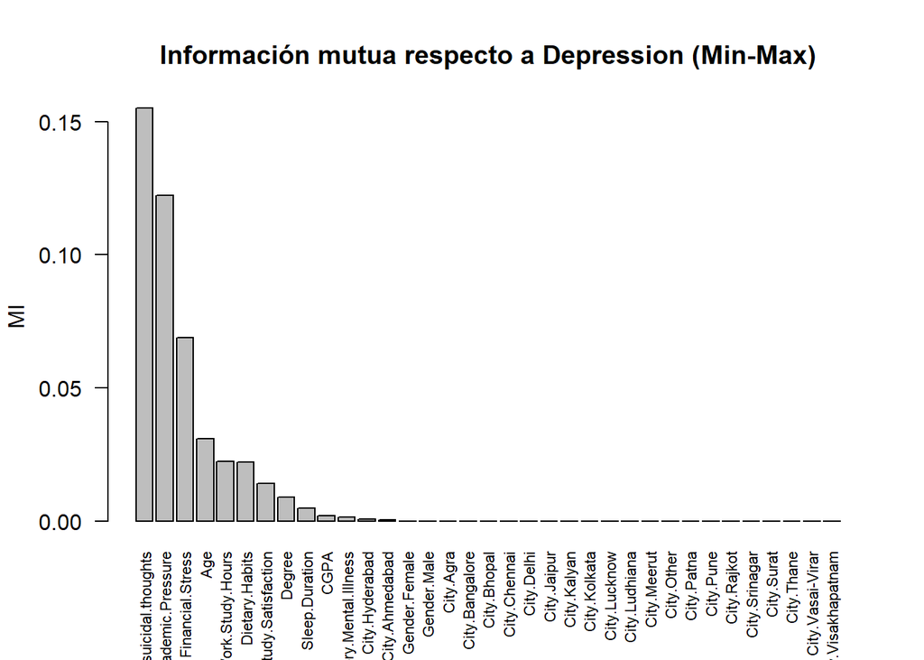

```r
barplot(
  mi_minmax_sorted$attr_importance,
  names.arg = rownames(mi_minmax_sorted),
  las = 2,
  cex.names = 0.7,
  main = "Información mutua respecto a Depression (Min-Max)",
  ylab = "MI"
)
```

Seleccionamos las 11 variables más informativas según MI y construimos un nuevo dataset reducido:

```r
k_top <- 11

top_vars_minmax <- rownames(mi_minmax_sorted)[1:k_top]
top_vars_minmax
```

```
##  [1] "Had.suicidal.thoughts"         "Academic.Pressure"
##  [3] "Financial.Stress"              "Age"
##  [5] "Work.Study.Hours"              "Dietary.Habits"
##  [7] "Study.Satisfaction"            "Degree"
##  [9] "Sleep.Duration"                "CGPA"
## [11] "Family.History.Mental.Illness"
```

Construimos el dataset reducido (11 mejores variables + objetivo) y lo guardamos:

```r
df_numeric_minmax_mi <- df_numeric_minmax %>%
  dplyr::select(all_of(top_vars_minmax), Depression)

head(df_numeric_minmax_mi)
```

```
##   Had.suicidal.thoughts Academic.Pressure Financial.Stress       Age
## 1                     1               1.0             0.00 0.3658537
## 2                     0               0.4             0.25 0.1463415
## 3                     0               0.6             0.00 0.3170732
## 4                     1               0.6             1.00 0.2439024
## 5                     1               0.8             0.00 0.1707317
## 6                     0               0.4             0.00 0.2682927
##   Work.Study.Hours Dietary.Habits Study.Satisfaction    Degree Sleep.Duration
## 1       0.25000000            1.0                0.4 0.3333333      0.3333333
## 2       0.25000000            0.5                1.0 0.3333333      0.3333333
## 3       0.75000000            1.0                1.0 0.3333333      0.0000000
## 4       0.33333333            0.5                0.4 0.3333333      0.6666667
## 5       0.08333333            0.5                0.6 0.6666667      0.3333333
## 6       0.33333333            1.0                0.6 1.0000000      0.0000000
##        CGPA Family.History.Mental.Illness Depression
## 1 0.7927565                             0        Yes
## 2 0.1750503                             1         No
## 3 0.4024145                             1         No
## 4 0.1126761                             1        Yes
## 5 0.6237425                             0         No
## 6 0.1348089                             0         No
```

```r
write.csv(df_numeric_minmax_mi, "./data/student_depression_numeric_minmax_mi.csv",
          row.names = FALSE)
```

### 10.3. Dataset numérico y Standard Scaler (`df_numeric_standard`)

A partir del mismo dataset numérico `df_numeric_full` utilizado en el apartado anterior, aplicamos ahora un **escalado estándar** a las variables predictoras:

```r
cols_to_scale <- setdiff(names(df_numeric_full), "Depression")

process_standard <- preProcess(
  df_numeric_full[, cols_to_scale],
  method = c("center", "scale")
)
```

Aplicamos la transformación estándar a las variables predictoras:

```r
df_standard_values <- predict(process_standard, df_numeric_full[, cols_to_scale])
```

Reconstruimos el dataset añadiendo la variable objetivo sin escalar:

```r
df_numeric_standard <- df_standard_values %>%
  mutate(Depression = df_numeric_full$Depression)

head(df_numeric_standard)
```

```
##          Age Academic.Pressure       CGPA Study.Satisfaction Sleep.Duration
## 1  1.4636878         1.3453951  0.8953448        -0.69391252     -0.3542413
## 2 -0.3706759        -0.8265708 -1.2008888         1.51119962     -0.3542413
## 3  1.0560514        -0.1025822 -0.4293109         1.51119962     -1.2418567
## 4  0.4445969        -0.1025822 -1.4125606        -0.69391252      0.5333740
## 5 -0.1668577         0.6214064  0.3217826         0.04112486     -0.3542413
## 6  0.6484151        -0.8265708 -1.3374512         0.04112486     -1.2418567
##   Dietary.Habits     Degree Had.suicidal.thoughts Work.Study.Hours
## 1      1.3748389 -0.1371477             0.7619473       -1.1226157
## 2      0.1199654 -0.1371477            -1.3123795       -1.1226157
## 3      1.3748389 -0.1371477            -1.3123795        0.4963858
## 4      0.1199654 -0.1371477             0.7619473       -0.8527821
## 5      0.1199654  1.1909865             0.7619473       -1.6622829
## 6      1.3748389  2.5191207            -1.3123795       -0.8527821
##   Financial.Stress Family.History.Mental.Illness Gender.Female Gender.Male
```

[output cut: 41 more lines]

Y guardamos el dataset estandarizado:

```r
write.csv(df_numeric_standard, "./data/student_depression_numeric_standard.csv",
          row.names = FALSE)

head(df_numeric_standard)
```

```
##          Age Academic.Pressure       CGPA Study.Satisfaction Sleep.Duration
## 1  1.4636878         1.3453951  0.8953448        -0.69391252     -0.3542413
## 2 -0.3706759        -0.8265708 -1.2008888         1.51119962     -0.3542413
## 3  1.0560514        -0.1025822 -0.4293109         1.51119962     -1.2418567
## 4  0.4445969        -0.1025822 -1.4125606        -0.69391252      0.5333740
## 5 -0.1668577         0.6214064  0.3217826         0.04112486     -0.3542413
## 6  0.6484151        -0.8265708 -1.3374512         0.04112486     -1.2418567
##   Dietary.Habits     Degree Had.suicidal.thoughts Work.Study.Hours
## 1      1.3748389 -0.1371477             0.7619473       -1.1226157
## 2      0.1199654 -0.1371477            -1.3123795       -1.1226157
## 3      1.3748389 -0.1371477            -1.3123795        0.4963858
## 4      0.1199654 -0.1371477             0.7619473       -0.8527821
## 5      0.1199654  1.1909865             0.7619473       -1.6622829
## 6      1.3748389  2.5191207            -1.3123795       -0.8527821
##   Financial.Stress Family.History.Mental.Illness Gender.Female Gender.Male
```

[output cut: 41 more lines]

#### 10.3.1. Reducción de dimensionalidad mediante Información Mutua (dataset Standard Scaler)

La Información Mutua es **invariante ante transformaciones monótonas** como la normalización Min-Max o el escalado estándar (centrado y escalado). Por ello, el patrón de relevancia de las variables obtenido en el apartado 10.2.1 sigue siendo válido para el dataset estandarizado.

Aun así, por coherencia con la estructura del documento, recalculamos la MI sobre el dataset `df_numeric_standard`:

```r
df_mi_standard <- df_numeric_standard
df_mi_standard$Depression <- as.factor(df_mi_standard$Depression)

mi_standard <- information.gain(Depression ~ ., data = df_mi_standard)
mi_standard_sorted <- mi_standard[order(-mi_standard$attr_importance), , drop = FALSE]

mi_standard_sorted
```

```
##                               attr_importance
## Had.suicidal.thoughts            0.1550642918
## Academic.Pressure                0.1221631983
## Financial.Stress                 0.0687660810
## Age                              0.0308617811
## Work.Study.Hours                 0.0222966565
## Dietary.Habits                   0.0219934626
## Study.Satisfaction               0.0140666894
## Degree                           0.0089517108
## Sleep.Duration                   0.0048170115
## CGPA                             0.0018828426
## Family.History.Mental.Illness    0.0014195893
## City.Hyderabad                   0.0007643439
## City.Ahmedabad                   0.0005440761
## Gender.Female                    0.0000000000
## Gender.Male                      0.0000000000
## City.Agra                        0.0000000000
## City.Bangalore                   0.0000000000
## City.Bhopal                      0.0000000000
## City.Chennai                     0.0000000000
## City.Delhi                       0.0000000000
## City.Jaipur                      0.0000000000
## City.Kalyan                      0.0000000000
## City.Kolkata                     0.0000000000
## City.Lucknow                     0.0000000000
## City.Ludhiana                    0.0000000000
## City.Meerut                      0.0000000000
## City.Other                       0.0000000000
## City.Patna                       0.0000000000
## City.Pune                        0.0000000000
## City.Rajkot                      0.0000000000
## City.Srinagar                    0.0000000000
## City.Surat                       0.0000000000
## City.Thane                       0.0000000000
## City.Vasai-Virar                 0.0000000000
## City.Visakhapatnam               0.0000000000
```

Y mostramos su gráfico:

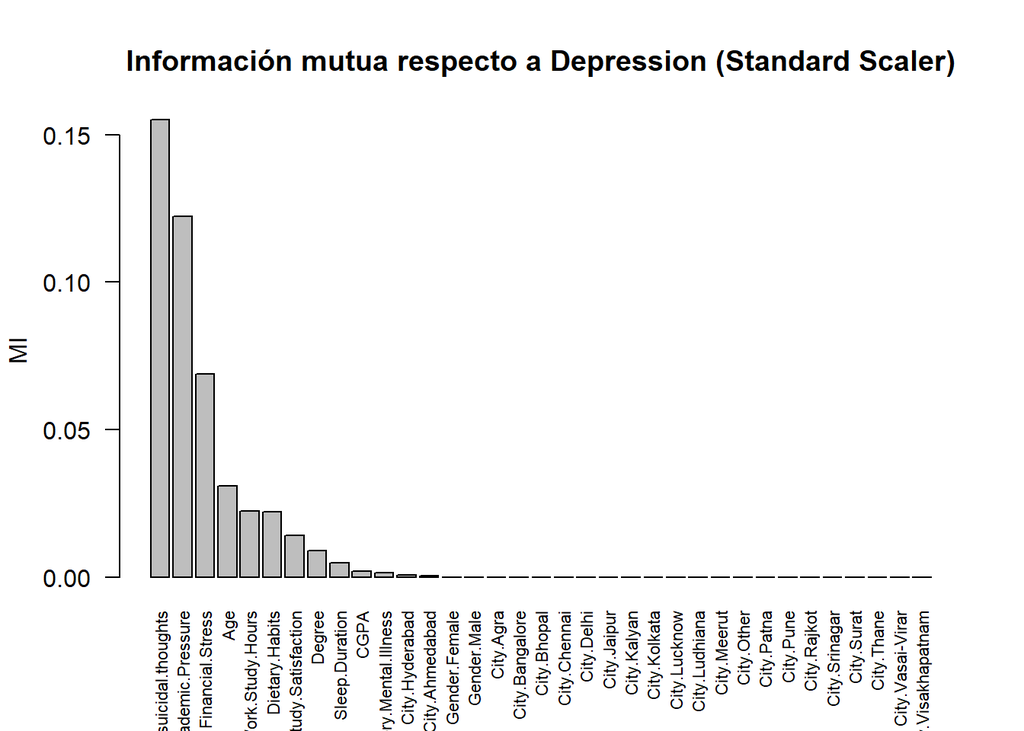

```r
barplot(
  mi_standard_sorted$attr_importance,
  names.arg = rownames(mi_standard_sorted),
  las = 2,
  cex.names = 0.7,
  main = "Información mutua respecto a Depression (Standard Scaler)",
  ylab = "MI"
)
```

Seleccionamos las 11 variables más informativas según MI y construimos un nuevo dataset reducido:

```r
k_top <- 11

top_vars_standard <- rownames(mi_standard_sorted)[1:k_top]
top_vars_standard
```

```
##  [1] "Had.suicidal.thoughts"         "Academic.Pressure"
##  [3] "Financial.Stress"              "Age"
##  [5] "Work.Study.Hours"              "Dietary.Habits"
##  [7] "Study.Satisfaction"            "Degree"
##  [9] "Sleep.Duration"                "CGPA"
## [11] "Family.History.Mental.Illness"
```

Construimos el dataset reducido (11 mejores variables + objetivo) y lo guardamos:

```r
df_numeric_standard_mi <- df_numeric_standard %>%
  dplyr::select(all_of(top_vars_standard), Depression)

head(df_numeric_standard_mi)
```

```
##   Had.suicidal.thoughts Academic.Pressure Financial.Stress        Age
## 1             0.7619473         1.3453951        -1.488559  1.4636878
## 2            -1.3123795        -0.8265708        -0.792760 -0.3706759
## 3            -1.3123795        -0.1025822        -1.488559  1.0560514
## 4             0.7619473        -0.1025822         1.294638  0.4445969
## 5             0.7619473         0.6214064        -1.488559 -0.1668577
## 6            -1.3123795        -0.8265708        -1.488559  0.6484151
##   Work.Study.Hours Dietary.Habits Study.Satisfaction     Degree Sleep.Duration
## 1       -1.1226157      1.3748389        -0.69391252 -0.1371477     -0.3542413
## 2       -1.1226157      0.1199654         1.51119962 -0.1371477     -0.3542413
## 3        0.4963858      1.3748389         1.51119962 -0.1371477     -1.2418567
## 4       -0.8527821      0.1199654        -0.69391252 -0.1371477      0.5333740
## 5       -1.6622829      0.1199654         0.04112486  1.1909865     -0.3542413
## 6       -0.8527821      1.3748389         0.04112486  2.5191207     -1.2418567
##         CGPA Family.History.Mental.Illness Depression
## 1  0.8953448                    -0.9686312        Yes
## 2 -1.2008888                     1.0323475         No
## 3 -0.4293109                     1.0323475         No
## 4 -1.4125606                     1.0323475        Yes
## 5  0.3217826                    -0.9686312         No
## 6 -1.3374512                    -0.9686312         No
```

```r
write.csv(df_numeric_standard_mi, "./data/student_depression_numeric_standard_mi.csv",
          row.names = FALSE)
```

## 11. Conclusiones

En este documento hemos llevado a cabo el preprocesamiento completo del dataset original sobre depresión estudiantil, con el objetivo de obtener una base de datos limpia, consistente y adecuada para distintas técnicas de minería de datos y modelado predictivo.

En primer lugar, hemos acotado el ámbito de estudio a la **población estudiante**, filtrando únicamente aquellos registros cuyo `Profession` es `"Student"` y eliminando variables sin valor informativo (identificadores y atributos constantes en este subgrupo). A continuación, se han corregido **valores inconsistentes** (como `"?"` en `Financial.Stress`), recodificado variables binarias a formato 0/1 y tratado de forma cuidadosa las **variables ordinales** (`Sleep.Duration`, `Dietary.Habits`), respetando el orden lógico de sus categorías.

También hemos abordado la **reducción de cardinalidad** en variables categóricas de alta dimensión, como `City` y `Degree`, agrupando niveles poco frecuentes o muy específicos en categorías más generales y manejables. Este paso reduce el riesgo de sobreajuste y facilita la interpretación posterior de los modelos. Por otro lado, se ha realizado una **gestión explícita de outliers** en la variable `CGPA` mediante el criterio del rango intercuartílico (IQR), evitando que valores extremos distorsionen los resultados de algoritmos sensibles a la escala y a la distancia.

Sobre esta base preprocesada se han generado diferentes **versiones del dataset**, adaptadas a distintos tipos de técnicas:

- Un dataset con factores (`student_depression_factors.csv`), pensado para modelos basados en árboles y análisis exploratorio.
- Un dataset numérico normalizado mediante **Min-Max** (`student_depression_numeric_minmax.csv`), adecuado para algoritmos basados en distancias.
- Un dataset numérico estandarizado (`student_depression_numeric_standard.csv`), orientado a modelos lineales y métodos que asumen variables centradas y escaladas.

Finalmente, se ha incorporado una **reducción de dimensionalidad basada en Información Mutua (MI)** entre cada variable y la variable objetivo `Depression`. Este enfoque permite capturar dependencias no lineales que no se reflejan en la simple correlación lineal, especialmente relevante en un problema de salud mental donde las relaciones entre factores suelen ser complejas. A partir de este análisis, se han construido dos datasets reducidos:

- `student_depression_numeric_minmax_mi.csv`
- `student_depression_numeric_standard_mi.csv`

ambos formados por las **11 variables más informativas según MI**, junto con la variable objetivo. Estas versiones reducidas proporcionan una base compacta y eficiente para el entrenamiento de modelos, mitigando la dimensionalidad sin perder las características más relevantes para la predicción de la depresión estudiantil.

En conjunto, el pipeline de preprocesamiento implementado garantiza que los datos utilizados en las fases posteriores de modelado sean de calidad, estén adecuadamente transformados y ofrezcan tanto **riqueza informativa** como **eficiencia computacional**, sentando una base sólida para el análisis de la depresión en población estudiantil.